# PAC4 - Tipologia i cicle de vida de les dades

N.Aguilera i J.A.Reina

20 de maig, 2021

# 1.- Descripció del dataset. Perquè és important i quina pregunta/problema pretén respondre?

El dataset s’ha obtingut de la web ‘https://www.kaggle.com/uciml/red-wine-quality-cortez-et-al-2009’ i dins d’aquesta s’ha descarregat el fitxer ‘winequality-red.csv’. El conjunt de dades d’aquest fitxer conté informació de la variant vermella del vi portugués anomenat *‘Vinho Verde’* que es va originar a la provincia del Minho en el extrem nord de Portugal. Concretament està format per variables fisicoquímiques i sensorials. Indicar que no conté informació dels tipus de raïm, marca, preu de venda, etc. que identifiquen un vi concret.

Sovint es diu que el gran vi s’elabora a la vinya, no al celler. No obstant això, els enòlegs tenen la capacitat de modificar certs aspectes dels vins que elaboren, com el nivell d’acidesa, dolçor o alcohol, així com la vida útil. Però quins aspectes han de modificar els enòlegs per afectar positivament les percepcions i/o vendes dels seus vins? El conèixement de determinades propietats fisioquímiques i la qualitat percebuda dels vins, permet prendre decisions més fonamentades durant la seva elaboració.

La característica del vi de major interès es la variable *quality*, que fa referència a la qualitat del vi negre. També té gran interès conèixer com la resta de variables afecten aquesta qualitat, que podrà estar determinada per una o vàries d’aquestes característiques o variables. L’objectiu serà realitzar diferents modelitzacions per veure la relació entre la qualitat del vi i la resta de components, característiques o proves fisicoquímicas.

Aquest conjunt de dades permeten realitzar tasques de classificació i regressió i per tant poden donar resposat a diferents preguntes o problemes que es plantegen:

- Quines propietats fisioquímiques determinen la qualitat d’un vi?
- Quines característiques d’aquest vi son les que tenen més influència en la determinació de la qualitat del vi? Es a dir, quines donen més informació sobre la seva qualitat?
- A partir dels components es pot predir si un vi serà bo?
- Es pot determinar quantes classes de vi existeixen, les seves qualitats i si aquests diferents nivells de qualitat s’han establert correctament?
- Existeixen paràmetres o regles per determinar la qualitat d’un vi?, quines son?

*Bibliografia*:

https://datauab.github.io/red_wine_quality/#:~:text=4.%20Data%20Cleaning%20and%20Checking%20%C2%B6%20%20,%20%201.9%20%206%20more%20rows%20

# 2.- Integració i selecció de les dades d’interès a analitzar.

En primer lloc es descarrega el fitxer *‘winequality-red.csv’* de la web https://www.kaggle.com/ a local. Després es carrega a *rStudio* reanomenant-lo a *wine_red* i es realitza un anàlisi de la seva estructura.

```r
wine_red <- read.csv("winequality-red.csv", sep=",", header=TRUE, stringsAsFactors = FALSE, na.strings = NA)
dim(wine_red)
```

```
## [1] 1599   12
```

```r
str(wine_red)
```

```
## 'data.frame':    1599 obs. of  12 variables:
##  $ fixed.acidity       : num  7.4 7.8 7.8 11.2 7.4 7.4 7.9 7.3 7.8 7.5 ...
##  $ volatile.acidity    : num  0.7 0.88 0.76 0.28 0.7 0.66 0.6 0.65 0.58 0.5 ...
##  $ citric.acid         : num  0 0 0.04 0.56 0 0 0.06 0 0.02 0.36 ...
##  $ residual.sugar      : num  1.9 2.6 2.3 1.9 1.9 1.8 1.6 1.2 2 6.1 ...
##  $ chlorides           : num  0.076 0.098 0.092 0.075 0.076 0.075 0.069 0.065 0.073 0.071 ...
##  $ free.sulfur.dioxide : num  11 25 15 17 11 13 15 15 9 17 ...
##  $ total.sulfur.dioxide: num  34 67 54 60 34 40 59 21 18 102 ...
##  $ density             : num  0.998 0.997 0.997 0.998 0.998 ...
##  $ pH                  : num  3.51 3.2 3.26 3.16 3.51 3.51 3.3 3.39 3.36 3.35 ...
##  $ sulphates           : num  0.56 0.68 0.65 0.58 0.56 0.56 0.46 0.47 0.57 0.8 ...
##  $ alcohol             : num  9.4 9.8 9.8 9.8 9.4 9.4 9.4 10 9.5 10.5 ...
##  $ quality             : int  5 5 5 6 5 5 5 7 7 5 ...
```

```r
head(wine_red,10)
```

```
##    fixed.acidity volatile.acidity citric.acid residual.sugar chlorides
## 1            7.4             0.70        0.00            1.9     0.076
## 2            7.8             0.88        0.00            2.6     0.098
## 3            7.8             0.76        0.04            2.3     0.092
## 4           11.2             0.28        0.56            1.9     0.075
## 5            7.4             0.70        0.00            1.9     0.076
## 6            7.4             0.66        0.00            1.8     0.075
## 7            7.9             0.60        0.06            1.6     0.069
## 8            7.3             0.65        0.00            1.2     0.065
## 9            7.8             0.58        0.02            2.0     0.073
## 10           7.5             0.50        0.36            6.1     0.071
##    free.sulfur.dioxide total.sulfur.dioxide density   pH sulphates alcohol
## 1                   11                   34  0.9978 3.51      0.56     9.4
## 2                   25                   67  0.9968 3.20      0.68     9.8
## 3                   15                   54  0.9970 3.26      0.65     9.8
```

[output cut: 18 more lines]

El fitxer està format per **1599 observacions i 12 variables** de tipus numèriques (11 son num i 1 int). El contingut de les variables corresponen a propietats organolèptiques que es detallen a continuació:

**Variables d’entrada** basades en test fisicoquímics:

*1 - fixed.acidity*: contingut d’acidesa degut a àcids no-volàtils (no s’evaporen amb facilitat). (*tartaric acid* - $g/dm^3$)

*2 - volatile.acidity*: contingut en àcids volàtils com l’àcid acètic. A nivells massa alts pot conduir a un gust desagradable de vinagre. (*acetic acid* - $g/dm^3$)

*3 - citric.acid*: contingut en àcid cítric. En petites quantitats pot afegir frescor i sabor als vins.($g/dm^3$)

*4 - residual.sugar*: Contingut residual en sucre, es a dir, la quantitat de sucre que queda després de les parades de fermentació. Per una banda es estrany trobar vins amb menys d’1 gram/litre i els vins de més de 45 grams/litre es consideren dolços. ($g/dm^3$)

*5 - chlorides*: la quantitat de sal en el vi. (*sodium chloride* - $g/dm^3$)

*6 - free.sulfur.dioxide*: Contingut en $SO_2$. La forma lliure d’$SO_2$ existeix en equilibri entre el $SO_2$ molecular (com un gas dissolt) i l’ió bisulfit. Prevé el creixement microbià i l’oxidació del vi. ($mg/dm^3$)

*7 - total.sulfur.dioxide*: contingut total en $SO_2$. Quantitat de formes lliures i lligades de $SO_2$. En baixes concentracions, el $SO_2$ es majoritàriament indetectable en vi. Però en concentraciobns gratuïtes de $SO_2$ de més de 50 ppm, $SO_2$ es fa evident al nas i al gust. ($mg/dm^3$)

*8 - density*: Densitat del vi, que depén dels sucres i del percentatge d’alcohol. ($g/cm^3$)

*9 - pH*: mesura de l’acidesa. Descriu com és d’àcid o bàsic un vi en una escala de 0 (molt àcid) a 14 (molt bàsic). La majoria dels vins es troben entre 3-4 a l’escala de PH.

*10 - sulphates*: Continguts en sulfats que es fan servir per aturar les fermentacions. Corrrespon a un additiu vitivinícola que pot contribuir als nivells de gas de diòxis de sofre ($SO_2$), que actua com a antimicrobià i antioxidant. (*potassium sulphate* - $g/dm3$)

*11 - alcohol*: indica el contingut en etanol. (% *by volume*)

**Variables de sortida** (basada en dades sensorials):

*12 - quality* (*score between 0 and 10*): nombre que correspon a la nota que indiquen els someliers segons la qualitat del vi que perceben.

Es mostra a continuació les estadístiques descriptives dels valors de cada variable del *dataset* de *wine_red*. Per això es farà servir la funció *summary()* que permetrà mostrar els valors màxim, mínim, els quartils, la mitjana i mediana.

```r
summary(wine_red)
```

```
##  fixed.acidity   volatile.acidity  citric.acid    residual.sugar
##  Min.   : 4.60   Min.   :0.1200   Min.   :0.000   Min.   : 0.900
##  1st Qu.: 7.10   1st Qu.:0.3900   1st Qu.:0.090   1st Qu.: 1.900
##  Median : 7.90   Median :0.5200   Median :0.260   Median : 2.200
##  Mean   : 8.32   Mean   :0.5278   Mean   :0.271   Mean   : 2.539
##  3rd Qu.: 9.20   3rd Qu.:0.6400   3rd Qu.:0.420   3rd Qu.: 2.600
##  Max.   :15.90   Max.   :1.5800   Max.   :1.000   Max.   :15.500
##    chlorides       free.sulfur.dioxide total.sulfur.dioxide    density
##  Min.   :0.01200   Min.   : 1.00       Min.   :  6.00       Min.   :0.9901
##  1st Qu.:0.07000   1st Qu.: 7.00       1st Qu.: 22.00       1st Qu.:0.9956
##  Median :0.07900   Median :14.00       Median : 38.00       Median :0.9968
##  Mean   :0.08747   Mean   :15.87       Mean   : 46.47       Mean   :0.9967
##  3rd Qu.:0.09000   3rd Qu.:21.00       3rd Qu.: 62.00       3rd Qu.:0.9978
##  Max.   :0.61100   Max.   :72.00       Max.   :289.00       Max.   :1.0037
##        pH          sulphates         alcohol         quality
##  Min.   :2.740   Min.   :0.3300   Min.   : 8.40   Min.   :3.000
##  1st Qu.:3.210   1st Qu.:0.5500   1st Qu.: 9.50   1st Qu.:5.000
##  Median :3.310   Median :0.6200   Median :10.20   Median :6.000
##  Mean   :3.311   Mean   :0.6581   Mean   :10.42   Mean   :5.636
##  3rd Qu.:3.400   3rd Qu.:0.7300   3rd Qu.:11.10   3rd Qu.:6.000
##  Max.   :4.010   Max.   :2.0000   Max.   :14.90   Max.   :8.000
```

Es pot observar que la majoria de vins tenen com a valor de la variable dependent *quality*, un valor entre 5 i 6, concretament un 82,5% son considerats mediocres; un 13,57% es poden considerar bons vins i el 3,94% es considerarien vins dolents.

Es pot considerar interessant establir una discretització o dicotomització de la variable per la realització de diferents modelitzacions. I segons si el valor es igual o major que 7, considerar un vi com a ‘bo’ i contràriament, considerar-lo com a ‘no bo’. Així es transformaria l’escala de 10 punts en una variable dicotómica (vins bons i la resta).

Es pot veure, també, que l’atribut *residual.sugar* té un valor mínim de 0.9 g/l, un màxim de 15.5g/l i una mitjana de 2.5g/l, el que indicaria una gran desviació respecte de la mitjana. Depenen d’aquest atribut el vi es podria classificar en:

- Sec: menys de 4 g/l.
- Semisec: de 12 a 18 g/l.
- Semidolç: de 18 a 45 g/l.
- Dolç: més de 45 g/l.

Per tant, tots els vins es troben entre secs i semisecs. Segons la mitjana serien secs.

```r
table(wine_red$residual.sugar)
```

```
##
##  0.9  1.2  1.3  1.4  1.5  1.6 1.65  1.7 1.75  1.8  1.9    2 2.05  2.1 2.15  2.2
##    2    8    5   35   30   58    2   76    2  129  117  156    2  128    2  131
## 2.25  2.3 2.35  2.4  2.5 2.55  2.6 2.65  2.7  2.8 2.85  2.9 2.95    3  3.1  3.2
##    1  109    1   86   84    1   79    1   39   49    1   24    1   25    7   15
##  3.3  3.4 3.45  3.5  3.6 3.65  3.7 3.75  3.8  3.9    4  4.1  4.2 4.25  4.3  4.4
##   11   15    1    2    8    1    4    1    8    6   11    6    5    1    8    4
##  4.5  4.6 4.65  4.7  4.8    5  5.1 5.15  5.2  5.4  5.5  5.6  5.7  5.8  5.9    6
##    4    6    2    1    3    1    5    1    3    1    8    6    1    4    3    4
##  6.1  6.2  6.3  6.4 6.55  6.6  6.7    7  7.2  7.3  7.5  7.8  7.9  8.1  8.3  8.6
##    4    3    2    3    2    2    2    1    1    1    1    2    3    2    3    1
##  8.8  8.9    9 10.7   11 12.9 13.4 13.8 13.9 15.4 15.5
##    2    1    1    1    2    1    1    2    1    2    1
```

Respecte a l’atribut *citric.acid* es detecten 132 observacions amb valor 0, el que seria una mica estrany ja que tot i que la presència de citric.acid en el raïm es poc abundant, sí està present en concentracions entre 0,1 i 1g/l.

```r
table(wine_red$citric.acid)
```

```
##
##    0 0.01 0.02 0.03 0.04 0.05 0.06 0.07 0.08 0.09  0.1 0.11 0.12 0.13 0.14 0.15
##  132   33   50   30   29   20   24   22   33   30   35   15   27   18   21   19
## 0.16 0.17 0.18 0.19  0.2 0.21 0.22 0.23 0.24 0.25 0.26 0.27 0.28 0.29  0.3 0.31
##    9   16   22   21   25   33   27   25   51   27   38   20   19   21   30   30
## 0.32 0.33 0.34 0.35 0.36 0.37 0.38 0.39  0.4 0.41 0.42 0.43 0.44 0.45 0.46 0.47
##   32   25   24   13   20   19   14   28   29   16   29   15   23   22   19   18
## 0.48 0.49  0.5 0.51 0.52 0.53 0.54 0.55 0.56 0.57 0.58 0.59  0.6 0.61 0.62 0.63
##   23   68   20   13   17   14   13   12    8    9    9    8    9    2    1   10
## 0.64 0.65 0.66 0.67 0.68 0.69  0.7 0.71 0.72 0.73 0.74 0.75 0.76 0.78 0.79    1
##    9    7   14    2   11    4    2    1    1    3    4    1    3    1    1    1
```

L *volatile.acidity* mitjana, es de 0.52grams. Un excès d’acidesa volàtil dona com a resultat un gust de vinagre dolent. Potser els vins que tenen una qualitat menor es troben en la cua dreta en la representació del nivell més alt d’acidesa.

L’atribut *total.sulfur.dioxide*, té una mitja de 46.47ppm i el valor màxim es 289, que es bastant alt, ja que el 75% es de 62 ppm.

L’atribut *alcohol* oscil·la entre el vi més lleuger amb un 8.4% i el més fort amb un 14.9%.

Finalment, com l’atribut *quality* no es una característica, sinó més aviat un resultat atribuït, caldria aplicar la funció *as.factor* per factoritzar-lo.

```r
wine_red$quality=as.factor(wine_red$quality)
```

Per tenir una primera aproximació al *dataset*, es realitza una visualització de la distribució de les dades amb histogrames.

[figure not shown]

```r
par(mfrow=c(1,3))
hist(wine_red$fixed.acidity, main = "Histograma de citric.acid", ylab = "Frecuencia")
hist(wine_red$volatile.acidity, main = "Histograma de volatile.acidity", ylab = "Frecuencia")
hist(wine_red$citric.acid, main = "Histograma de citric.acid", ylab = "Frecuencia")
```

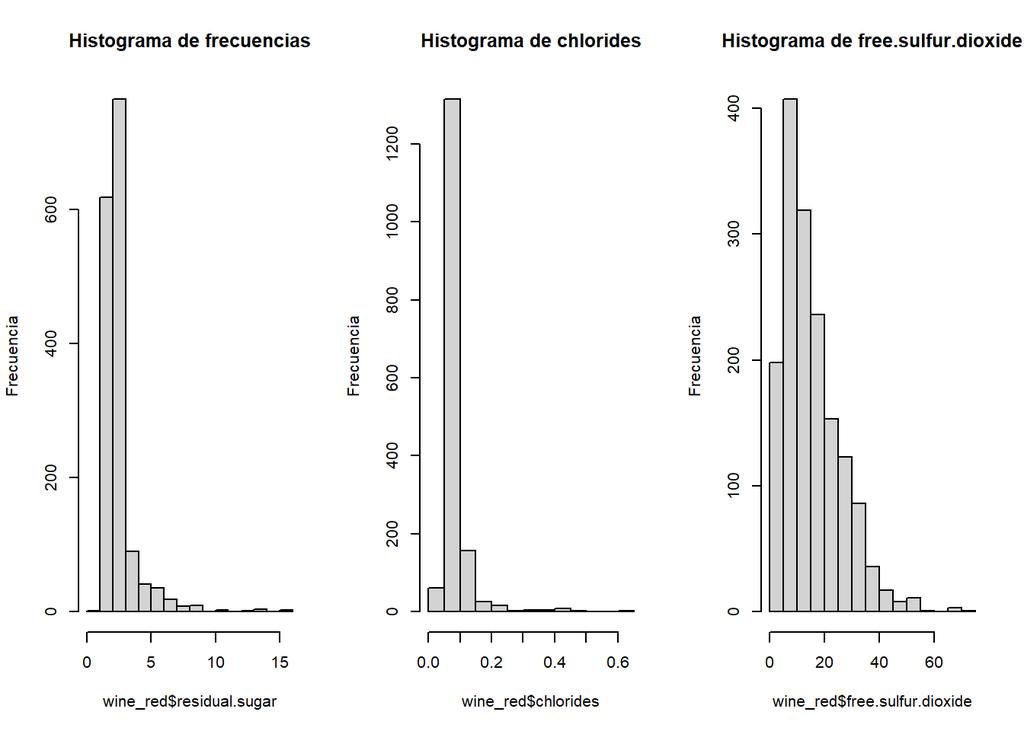

```r
hist(wine_red$residual.sugar, main = "Histograma de frecuencias", ylab = "Frecuencia")
hist(wine_red$chlorides, main = "Histograma de chlorides", ylab = "Frecuencia")
hist(wine_red$free.sulfur.dioxide, main = "Histograma de free.sulfur.dioxide", ylab = "Frecuencia")
```

[figure not shown]

```r
hist(wine_red$total.sulfur.dioxide, main = "Histograma de total.sulfur.dioxide", ylab = "Frecuencia")
hist(wine_red$density, main = "Histograma de pH", ylab = "Frecuencia")
hist(wine_red$pH, main = "Histograma de citric.acid", ylab = "Frecuencia")
```

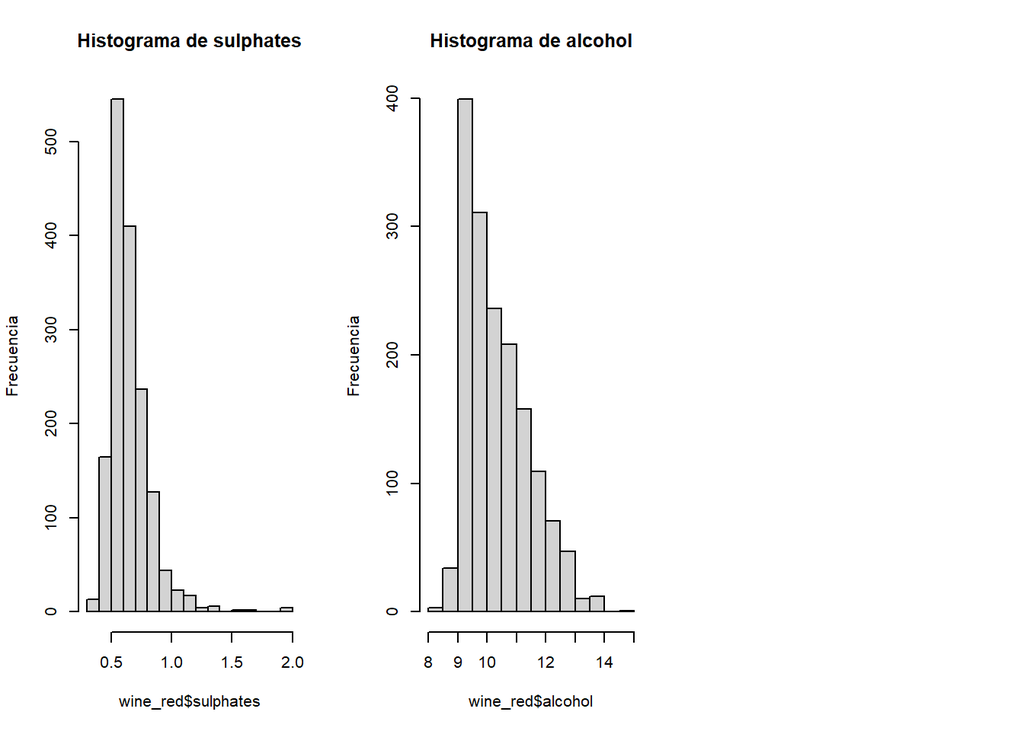

```r
hist(wine_red$sulphates, main = "Histograma de sulphates", ylab = "Frecuencia")
hist(wine_red$alcohol, main = "Histograma de alcohol", ylab = "Frecuencia")
```

On es pot veure, tot i que s’aprofundirà més endavant, que els diferents atributs o variables segueixen, amb alguns matisos, distribucions aparentment normals (amb assimetries, biaixos, cues, etc). Indicar a mode d’exemple, que la distribució de l’atribut *alcohol* sembla ser positivament esbiaixada, és a dir, la corba es desplaça cap a l’esquerra. Els atributs *densitat* i *pH* sí semblen seguir distribucions normals.

*Bibliografia*:

https://en.wikipedia.org/wiki/Acids_in_wine#Citric_acid

https://www.vinosycavasonline.es/los-aacidos-del-vino.-quae-son-y-caomo-se-forman.

https://catatu.es/blog/el-azucar-en-el-vino/#:~:text=Los%20vinos%20tranquilos%20se%20rigen%20por%20la%20cantidad,18%20g%2Fl%20Semidulce%3A%20de%2018%20a%2045%20g%2Fl

# 3.- Neteja de les dades.

Es realitza un procès de neteja de dades abans de realitzar les diferents modelitzacions, revisant i tractant les dades que contenen zeros o elements buits i valors extrems.

## 3.1.- Les dades contenen zeros o elements buits? Com gestionaries aquests casos?

Es verifica inicialment si existeixen dades al *dataset* que contenen elements buits representats amb el valor *NA*. Observant que no es detecta cap d’aquests valors. A més a més, d’haver-hi, haurien sortit en la funció *summary()*, anteriorment executada.

En cas que haguessin dades amb valors buits, *NA*, no es podria recuperar la informació buida ja que no es tracta d’una base de dades mostra i resultaria extremadament complicat intentar completar els camps buits tornant a obtenir la informació de l’anàlisi dels vins. Per tant, una posibilitat seria eliminar els registres que contenen valors buits.

Es comprova el nombre d’*NA* per cada atribut:

```r
nas <- lapply(wine_red, function(x){ sum(is.na(x))})
nas
```

```
## $fixed.acidity
## [1] 0
##
## $volatile.acidity
## [1] 0
##
## $citric.acid
## [1] 0
##
## $residual.sugar
## [1] 0
##
## $chlorides
## [1] 0
##
## $free.sulfur.dioxide
## [1] 0
##
## $total.sulfur.dioxide
## [1] 0
##
## $density
## [1] 0
##
## $pH
## [1] 0
##
## $sulphates
## [1] 0
##
## $alcohol
## [1] 0
##
## $quality
## [1] 0
```

Ara, es comprova el nombre de zeros de cada atribut:

```r
zeros <- lapply(wine_red, function(x){ length(which(x==0))})
zeros
```

```
## $fixed.acidity
## [1] 0
##
## $volatile.acidity
## [1] 0
##
## $citric.acid
## [1] 132
##
## $residual.sugar
## [1] 0
##
## $chlorides
## [1] 0
##
## $free.sulfur.dioxide
## [1] 0
##
## $total.sulfur.dioxide
## [1] 0
##
## $density
## [1] 0
##
## $pH
## [1] 0
##
## $sulphates
## [1] 0
##
## $alcohol
## [1] 0
##
## $quality
## [1] 0
```

I també es comprova el nombre de "" de cada atribut:

```r
buits <- lapply(wine_red, function(x){ length(which(x==""))})
buits
```

```
## $fixed.acidity
## [1] 0
##
## $volatile.acidity
## [1] 0
##
## $citric.acid
## [1] 0
##
## $residual.sugar
## [1] 0
##
## $chlorides
## [1] 0
##
## $free.sulfur.dioxide
## [1] 0
##
## $total.sulfur.dioxide
## [1] 0
##
## $density
## [1] 0
##
## $pH
## [1] 0
##
## $sulphates
## [1] 0
##
## $alcohol
## [1] 0
##
## $quality
## [1] 0
```

Es detecten zeros a l’atribut *citric.acid*, concretament 132 observacions. Com s’ha comentat abans, tot i que la presencia de *citric.acid* en el raïm es poc abundant, sí està present en concentracions entre 0,1 i 1g/l. Per tant, es pot considerar que hauria de tenir algun valor diferent de zero, el fet de tenir-lo es considera com a valor perdut.

Per decidir imputar algun valor, caldria tenir en compte per aquestes 132 observacions de *citric.acid*, a quin grup de *quality* pertanyen. De forma que es podria veure com es troben distribuides. Aplicant després algun mètode per imputar valor a aquests zeros.

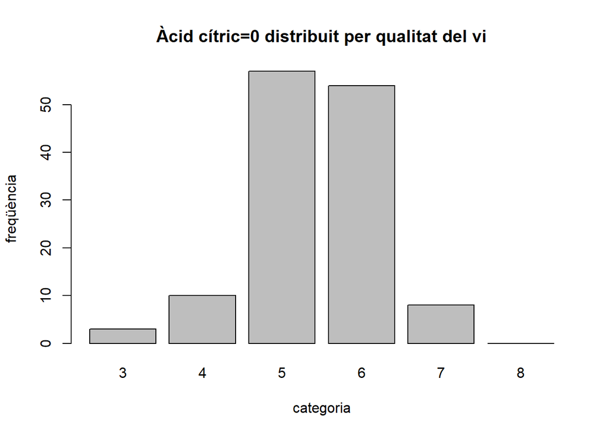

```r
# Creem un dataframe on hi han el valors 0
citric.acid.zeros = subset(wine_red, wine_red$citric.acid==0)
# Es realitza plot per veure la distribució
plot(citric.acid.zeros$quality, main="Àcid cítric=0 distribuit per qualitat del vi", xlab="categoria", ylab= "freqüència")
```

Com es veu al gràfic, les categories 5 i 6 son les que més zeros tenen.

```r
# Càlculem el percentatge de valors 0 a àcid cítric per cada categoria del vi respecte al dataset de wine_red:
citric.acid.zeros.p=round(100*table(citric.acid.zeros$quality)/table(wine_red$quality), 1)
citric.acid.zeros.p
```

```
##
##    3    4    5    6    7    8
## 30.0 18.9  8.4  8.5  4.0  0.0
```

Per imputar els valors perduts es poden aplicar diferents tècniques com la *imputació de la mitjana*, on els valors perduts es substitueixen per la mitjana aritmètica dels valors observats. Un altre seria la *imputació per regressió*, a partir d’obtenir un model regressiu (conjunt d’equacions de regresió), on els coeficients es cosntrueixen a partir de les dades existents. Aquestes equacions modelaran el comportament de la variable dependent o explicada i servirà per calcular els valors de les dades perdudes a partir de les variables independents o explicatives.

En aquest treball s’aplicarà l’algorisme dels *K-veins més propers (KNN)*. Seleccionant els k casos més propers al cas a imputar i posteriorment utilitzant-los per substituir el valor perdut per un imputat. Es farà mitjançant algun tipus de mètode que normalment es la mitjana aritmètica o la moda, depenent de si es tracta de variables continues o discretes (categóriques).

Entrant en la imputació de valors perduts, en primer lloc se substitueixen aquest zeros de la variable *citric.acid* per valors *NA*:

```r
# Es converteix els 0 en NAs per poder aplicar l'algoritme de KNN
wine_red$citric.acid[wine_red$citric.acid == 0] <- NA
summary(wine_red)
```

```
##  fixed.acidity   volatile.acidity  citric.acid     residual.sugar
##  Min.   : 4.60   Min.   :0.1200   Min.   :0.0100   Min.   : 0.900
##  1st Qu.: 7.10   1st Qu.:0.3900   1st Qu.:0.1400   1st Qu.: 1.900
##  Median : 7.90   Median :0.5200   Median :0.2800   Median : 2.200
##  Mean   : 8.32   Mean   :0.5278   Mean   :0.2954   Mean   : 2.539
##  3rd Qu.: 9.20   3rd Qu.:0.6400   3rd Qu.:0.4400   3rd Qu.: 2.600
##  Max.   :15.90   Max.   :1.5800   Max.   :1.0000   Max.   :15.500
##                                   NA's   :132
##    chlorides       free.sulfur.dioxide total.sulfur.dioxide    density
##  Min.   :0.01200   Min.   : 1.00       Min.   :  6.00       Min.   :0.9901
##  1st Qu.:0.07000   1st Qu.: 7.00       1st Qu.: 22.00       1st Qu.:0.9956
##  Median :0.07900   Median :14.00       Median : 38.00       Median :0.9968
##  Mean   :0.08747   Mean   :15.87       Mean   : 46.47       Mean   :0.9967
##  3rd Qu.:0.09000   3rd Qu.:21.00       3rd Qu.: 62.00       3rd Qu.:0.9978
##  Max.   :0.61100   Max.   :72.00       Max.   :289.00       Max.   :1.0037
##
##        pH          sulphates         alcohol      quality
##  Min.   :2.740   Min.   :0.3300   Min.   : 8.40   3: 10
##  1st Qu.:3.210   1st Qu.:0.5500   1st Qu.: 9.50   4: 53
##  Median :3.310   Median :0.6200   Median :10.20   5:681
##  Mean   :3.311   Mean   :0.6581   Mean   :10.42   6:638
##  3rd Qu.:3.400   3rd Qu.:0.7300   3rd Qu.:11.10   7:199
##  Max.   :4.010   Max.   :2.0000   Max.   :14.90   8: 18
##
```

I després s’aplica l’algorisme *kNN* per fer la imputació d’aquests valors *NA*:

```r
# Creem un nou dataframe on guardar les dades amb imputacions:
wine_red_x2=NULL
# Iterem per a cada valor de quality, tenint en compte que el valor mínim es 3 i el màxim es 8:
for (i in (3:8)){
  # Delimitem cada grup:
  wine_red_xquality=subset(wine_red, wine_red$quality==i)
  # Fem les imputacions amb kNN():
  vi_imputat = kNN(wine_red_xquality)
  # Afegim el resultat al nou dataframe, eliminant les columnes informatives, només agafem les variables amb valors
  wine_red_x2=rbind(wine_red_x2, vi_imputat[,1:12])
}

# Comprovem que no retorna valors 0 o NA
summary(wine_red_x2$citric.acid)
```

```
##    Min. 1st Qu.  Median    Mean 3rd Qu.    Max.
##  0.0100  0.1100  0.2600  0.2802  0.4200  1.0000
```

## 3.2.- Identificació i tractament de valors extrems.

Per tenir una major precissió en la informació a identificar i en el tractament de valors extrems, es realitzarà l’estudi per cada variable del *dataset* i dins de cada variable s’agruparà per cada qualitat del vi. Per tant, cada variable s’estudiarà a partir dels diferents grups per qualitat del vi (que conté valors entre 3 i 8), amb un total de 6 grups per cada variable. Això permetrà calcular els *outliers* per sustituir amb valors propers que tenen el mateix valor de qualitat del vi.

```r
outlierKD <- function(dt, var, nom, i, j) {
     var_name <- eval(substitute(var),eval(dt))
     na1 <- sum(is.na(var_name))
     m1 <- mean(var_name, na.rm = T)
     par(mfrow=c(2, 2), oma=c(0,0,3,0))
     boxplot(var_name, main="With outliers")
     hist(var_name, main="With outliers", xlab=NA, ylab=NA)
     outlier <- boxplot.stats(var_name)$out
     mo <- mean(outlier)
     var_name <- ifelse(var_name %in% outlier, NA, var_name)
     boxplot(var_name, main="Without outliers")
     hist(var_name, main="Without outliers", xlab=NA, ylab=NA)
     title_main = paste("Valida outliers",colnames(dt)[j], " per quality", i, sep=" ")
     title(main=title_main, outer=TRUE)
     na2 <- sum(is.na(var_name))

     cat("Outliers identificats per la qualitat del vi:", i, ": ", na2 - na1, "\n")
     cat("Proporció (%) de outliers:", round((na2 - na1) / sum(!is.na(var_name))*100, 1), "\n")
     cat("Mitja dels outliers:", round(mo, 2), "\n")
     m2 <- mean(var_name, na.rm = T)
     cat("Mitja sense eliminar els outliers:", round(m1, 2), "\n")
     cat("Mitja eliminant outliers:", round(m2, 2), "\n")
      # Guardem els outliers en una llista:

     for (k in outlier){
      # Cerquem per a cada columna els valors extrems i els substituïm per la mediana:
      dt[j][dt[j]==k]=round(mo, 2)
     }

     return(dt)
}
```

```r
wine_red_x3 <- NULL

for (i in (3:8)){
  # Obtenim totes les variables per un grup de qualitat de vi
  wine_quality <- subset(wine_red_x2, wine_red_x2$quality==i)
  # Per cada variable s'actualitzarà 'wine_quality' amb el tractament d'outliers corresponent
  wine_quality <- outlierKD(wine_quality, fixed.acidity, "fixed.acidity", i, 1)
  wine_quality <- outlierKD(wine_quality, volatile.acidity, "volatile.acidity", i, 2)
  wine_quality <- outlierKD(wine_quality, citric.acid, "citric.acid", i, 3)
  wine_quality <- outlierKD(wine_quality, residual.sugar, "residual.sugar", i, 4)
  wine_quality <- outlierKD(wine_quality, chlorides, "chlorides", i, 5)
  wine_quality <- outlierKD(wine_quality, free.sulfur.dioxide, "free.sulfur.dioxide", i, 6)
  wine_quality <- outlierKD(wine_quality, total.sulfur.dioxide, "total.sulfur.dioxide", i, 7)
  wine_quality <- outlierKD(wine_quality, density, "density", i, 8)
  wine_quality <- outlierKD(wine_quality, pH, "pH", i, 9)
  wine_quality <- outlierKD(wine_quality, sulphates, "sulphates", i, 10)
  wine_quality <- outlierKD(wine_quality, alcohol, "alcohol", i, 11)
  # Actualització de totes les variables del dataset per un grup de quality concret.
  wine_red_x3=rbind(wine_red_x3, wine_quality)
}
```

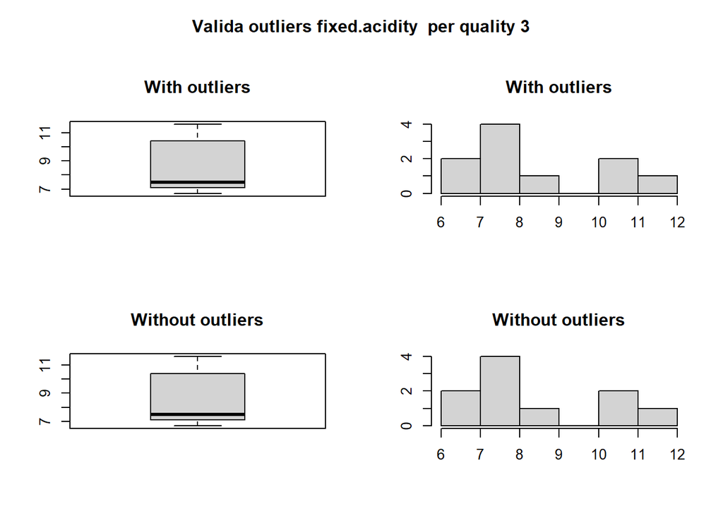

```
## Outliers identificats per la qualitat del vi: 3 :  0
## Proporció (%) de outliers: 0
## Mitja dels outliers: NaN
## Mitja sense eliminar els outliers: 8.36
## Mitja eliminant outliers: 8.36
```

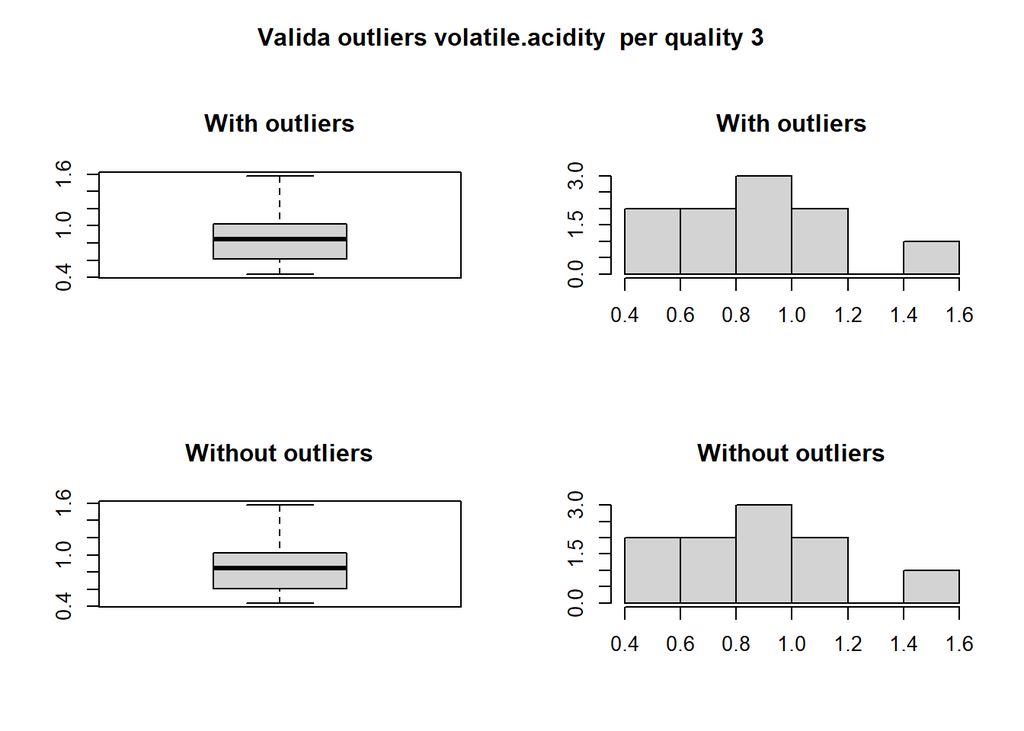

```
## Outliers identificats per la qualitat del vi: 3 :  0
## Proporció (%) de outliers: 0
## Mitja dels outliers: NaN
## Mitja sense eliminar els outliers: 0.88
## Mitja eliminant outliers: 0.88
```

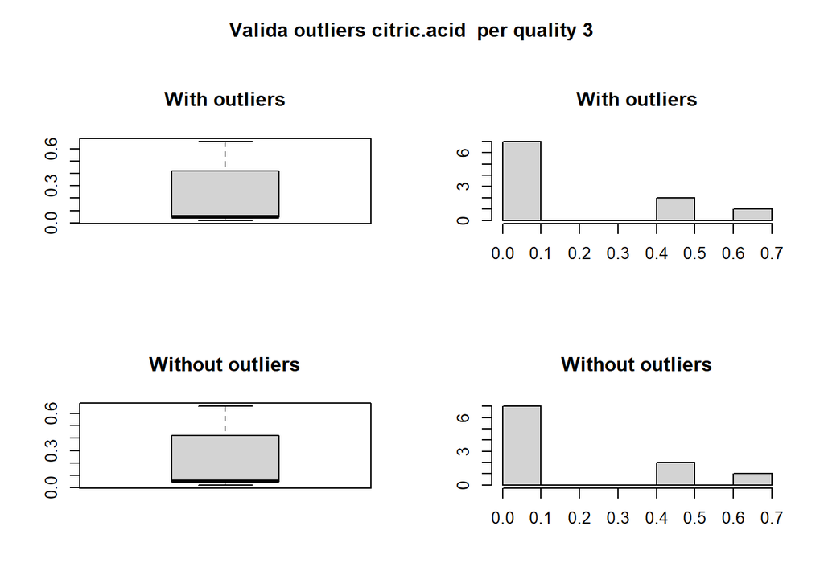

```
## Outliers identificats per la qualitat del vi: 3 :  0
## Proporció (%) de outliers: 0
## Mitja dels outliers: NaN
## Mitja sense eliminar els outliers: 0.19
## Mitja eliminant outliers: 0.19
```

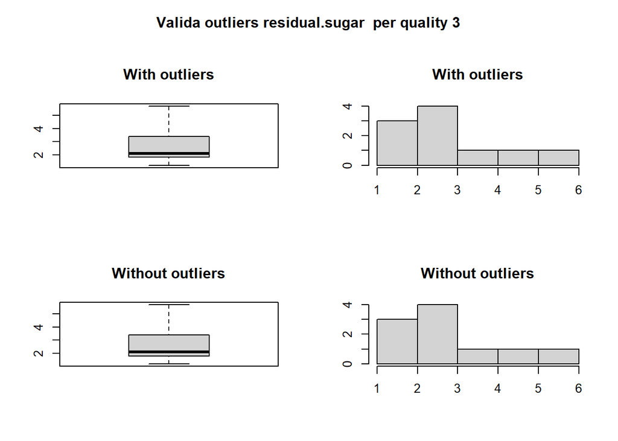

```
## Outliers identificats per la qualitat del vi: 3 :  0
## Proporció (%) de outliers: 0
## Mitja dels outliers: NaN
## Mitja sense eliminar els outliers: 2.64
## Mitja eliminant outliers: 2.64
```

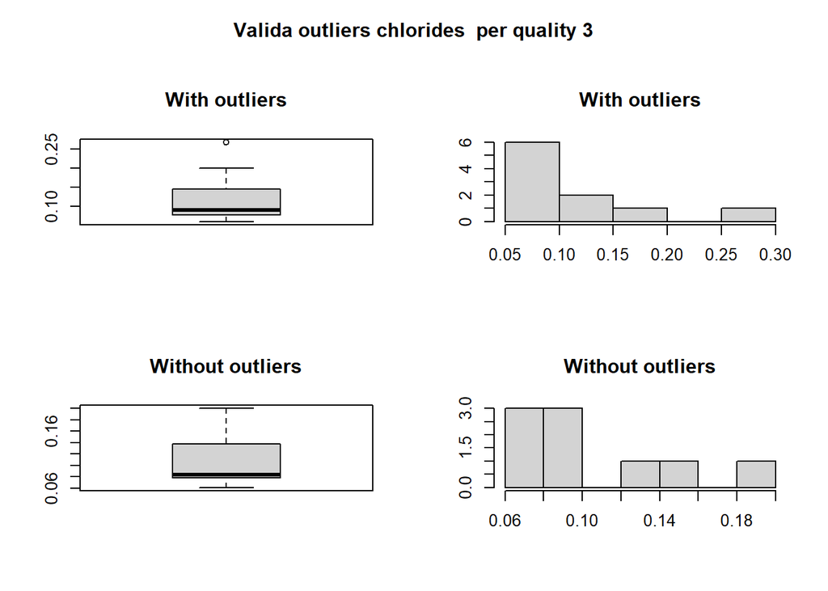

```
## Outliers identificats per la qualitat del vi: 3 :  1
## Proporció (%) de outliers: 11.1
## Mitja dels outliers: 0.27
## Mitja sense eliminar els outliers: 0.12
## Mitja eliminant outliers: 0.11
```

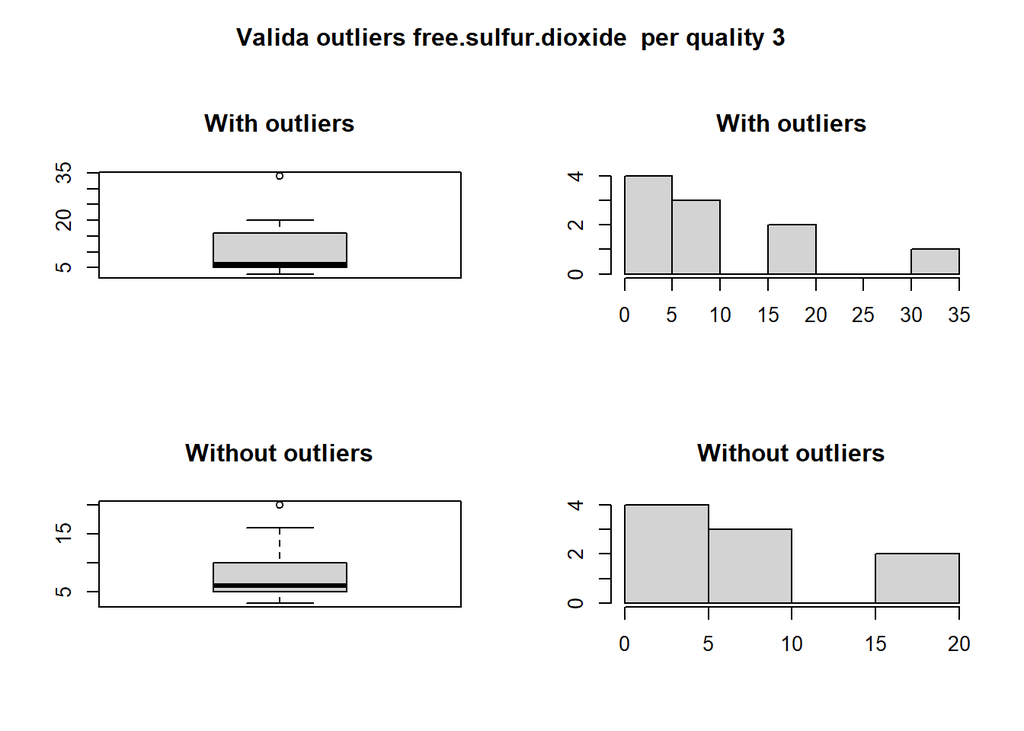

```
## Outliers identificats per la qualitat del vi: 3 :  1
## Proporció (%) de outliers: 11.1
## Mitja dels outliers: 34
## Mitja sense eliminar els outliers: 11
## Mitja eliminant outliers: 8.44
```

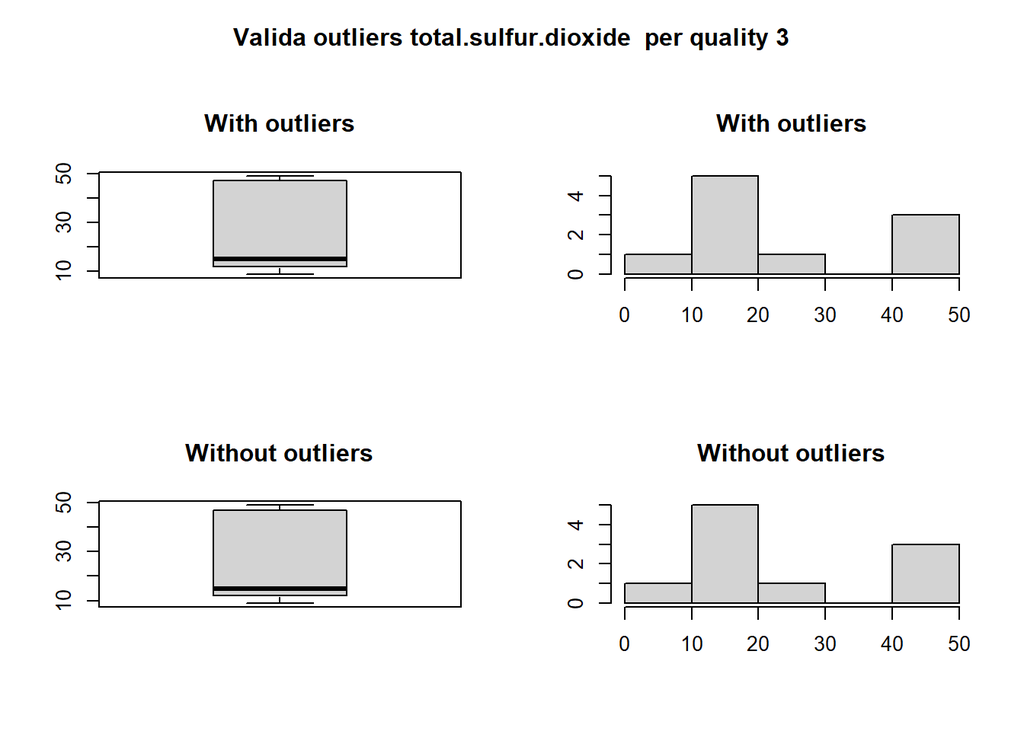

```
## Outliers identificats per la qualitat del vi: 3 :  0
## Proporció (%) de outliers: 0
## Mitja dels outliers: NaN
## Mitja sense eliminar els outliers: 24.9
## Mitja eliminant outliers: 24.9
```

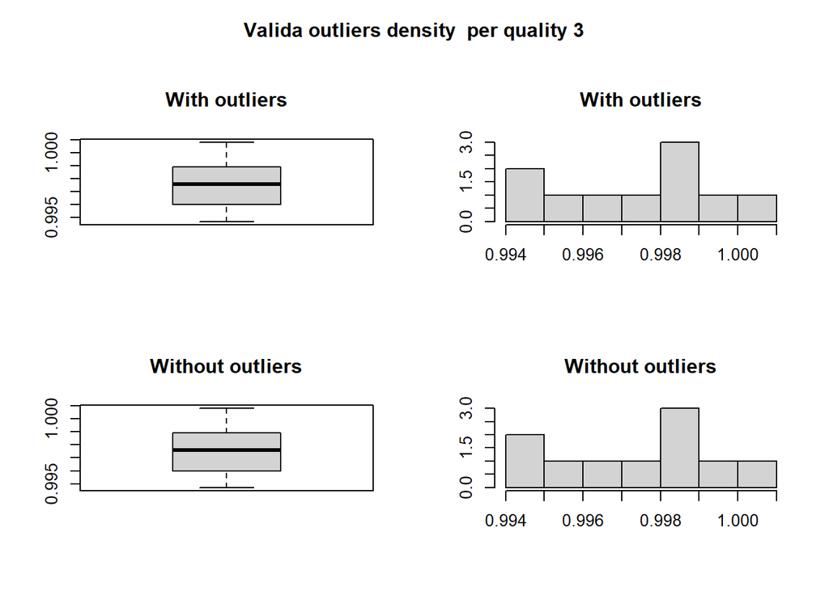

```
## Outliers identificats per la qualitat del vi: 3 :  0
## Proporció (%) de outliers: 0
## Mitja dels outliers: NaN
## Mitja sense eliminar els outliers: 1
## Mitja eliminant outliers: 1
```

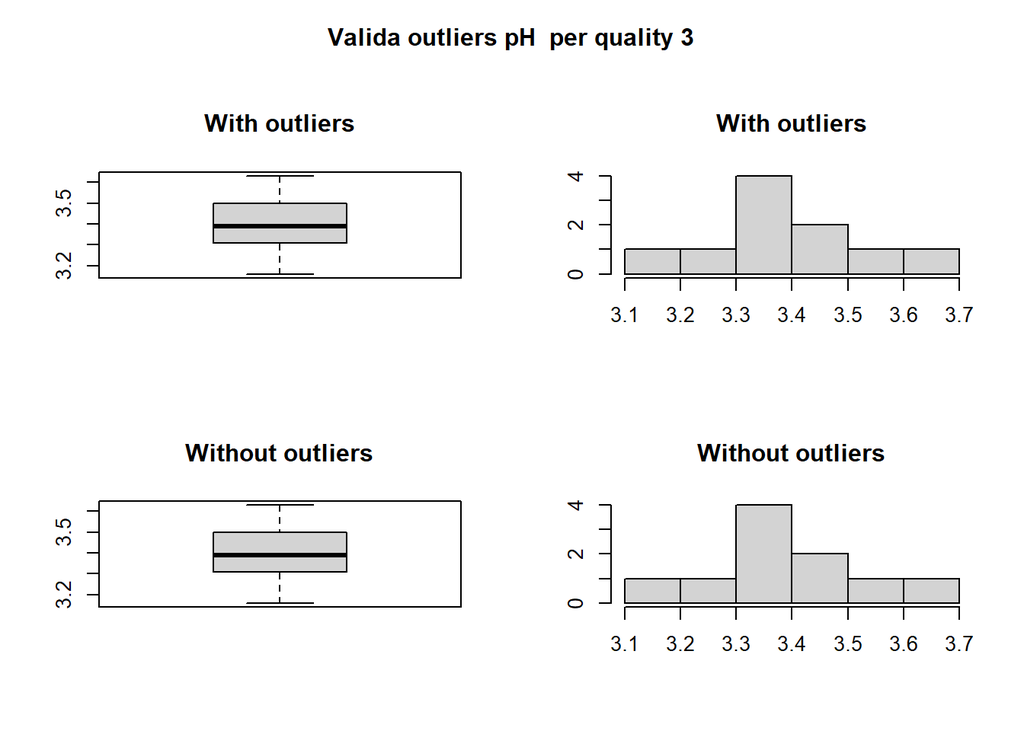

```
## Outliers identificats per la qualitat del vi: 3 :  0
## Proporció (%) de outliers: 0
## Mitja dels outliers: NaN
## Mitja sense eliminar els outliers: 3.4
## Mitja eliminant outliers: 3.4
```

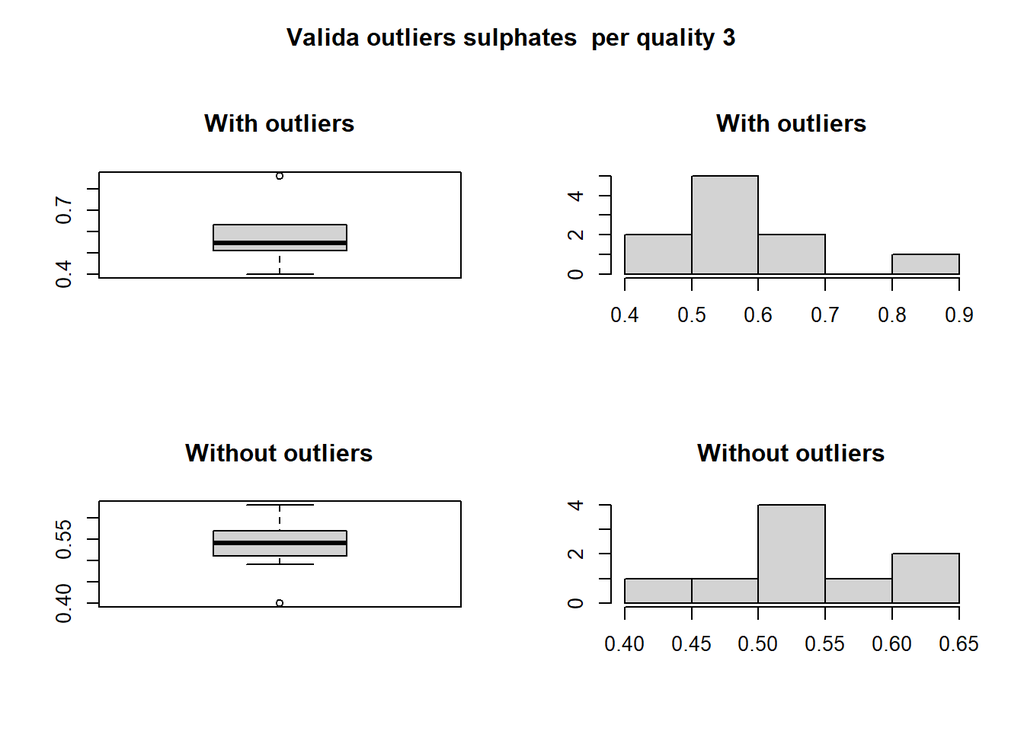

```
## Outliers identificats per la qualitat del vi: 3 :  1
## Proporció (%) de outliers: 11.1
## Mitja dels outliers: 0.86
## Mitja sense eliminar els outliers: 0.57
## Mitja eliminant outliers: 0.54
```

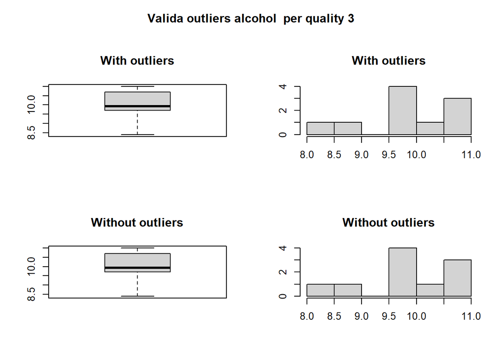

```
## Outliers identificats per la qualitat del vi: 3 :  0
## Proporció (%) de outliers: 0
## Mitja dels outliers: NaN
## Mitja sense eliminar els outliers: 9.96
## Mitja eliminant outliers: 9.96
```

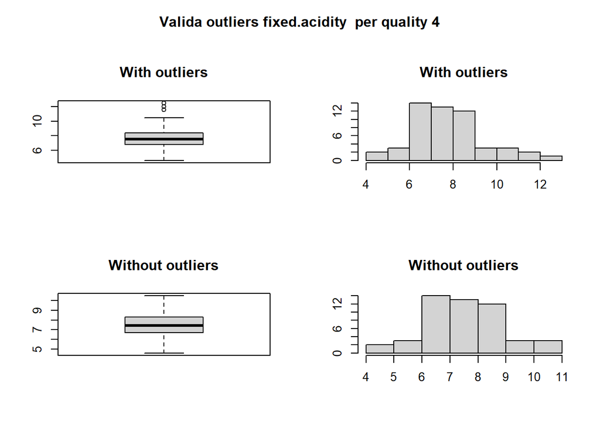

```
## Outliers identificats per la qualitat del vi: 4 :  3
## Proporció (%) de outliers: 6
## Mitja dels outliers: 12.03
## Mitja sense eliminar els outliers: 7.78
## Mitja eliminant outliers: 7.52
```

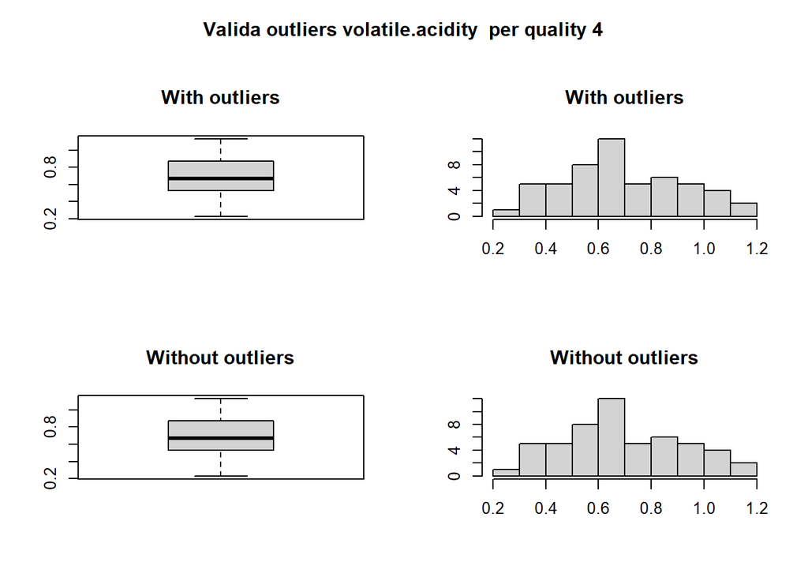

```
## Outliers identificats per la qualitat del vi: 4 :  0
## Proporció (%) de outliers: 0
## Mitja dels outliers: NaN
## Mitja sense eliminar els outliers: 0.69
## Mitja eliminant outliers: 0.69
```

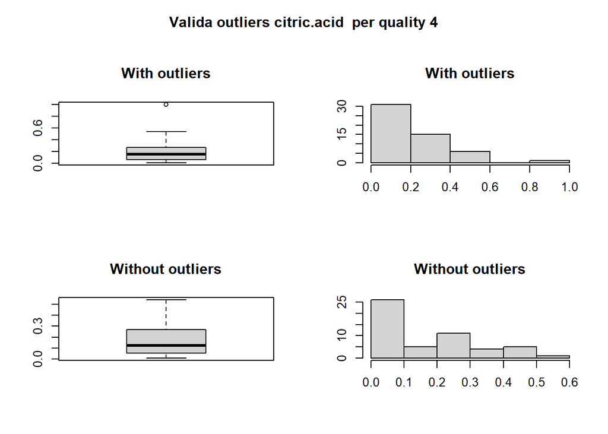

```
## Outliers identificats per la qualitat del vi: 4 :  1
## Proporció (%) de outliers: 1.9
## Mitja dels outliers: 1
## Mitja sense eliminar els outliers: 0.2
## Mitja eliminant outliers: 0.18
```

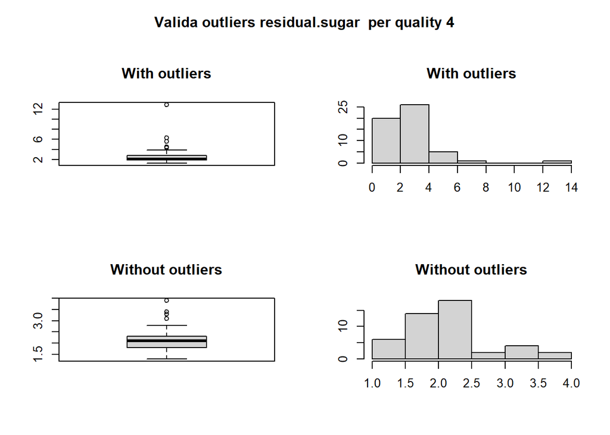

```
## Outliers identificats per la qualitat del vi: 4 :  7
## Proporció (%) de outliers: 15.2
## Mitja dels outliers: 6.06
## Mitja sense eliminar els outliers: 2.69
## Mitja eliminant outliers: 2.18
```

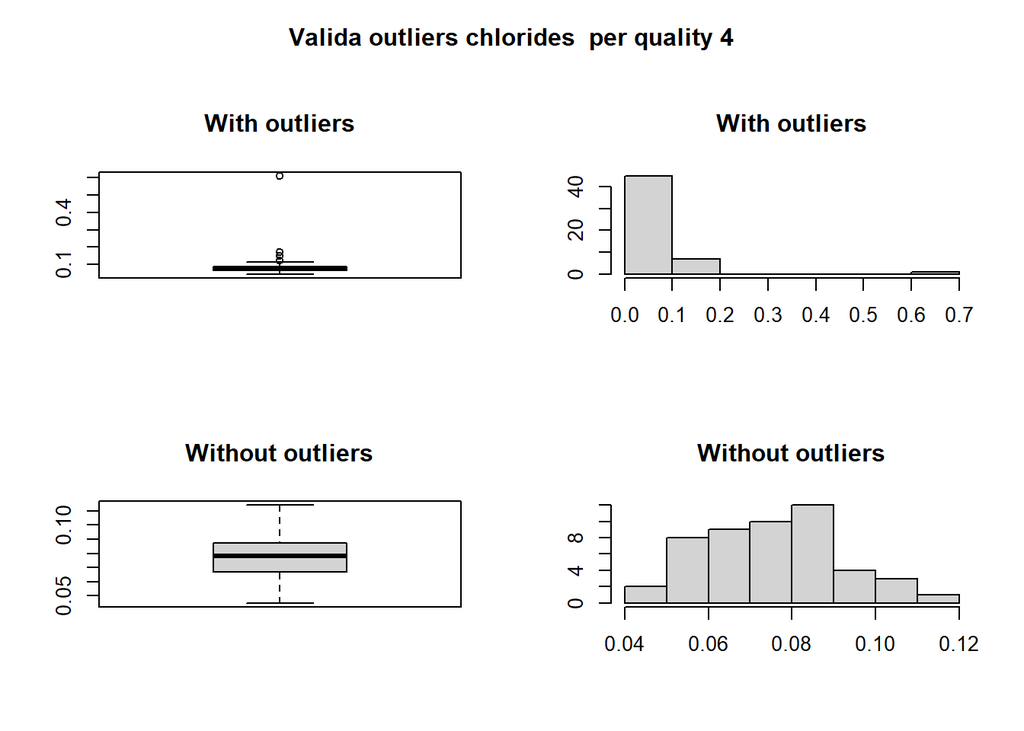

```
## Outliers identificats per la qualitat del vi: 4 :  4
## Proporció (%) de outliers: 8.2
## Mitja dels outliers: 0.26
## Mitja sense eliminar els outliers: 0.09
## Mitja eliminant outliers: 0.08
```

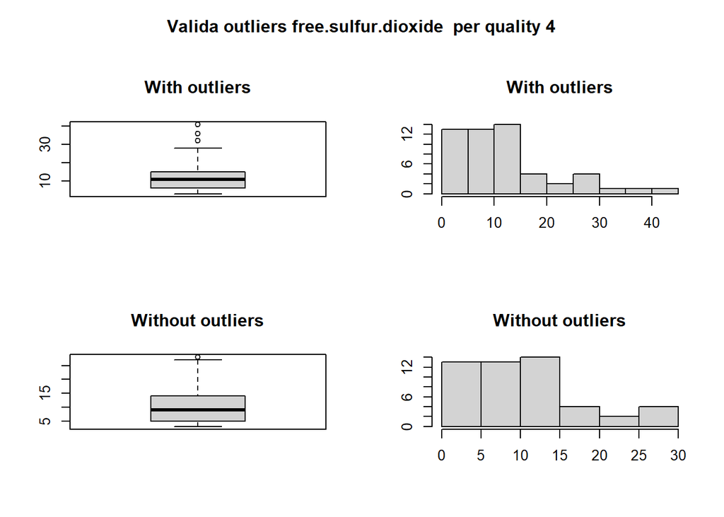

```
## Outliers identificats per la qualitat del vi: 4 :  3
## Proporció (%) de outliers: 6
## Mitja dels outliers: 36.33
## Mitja sense eliminar els outliers: 12.26
## Mitja eliminant outliers: 10.82
```

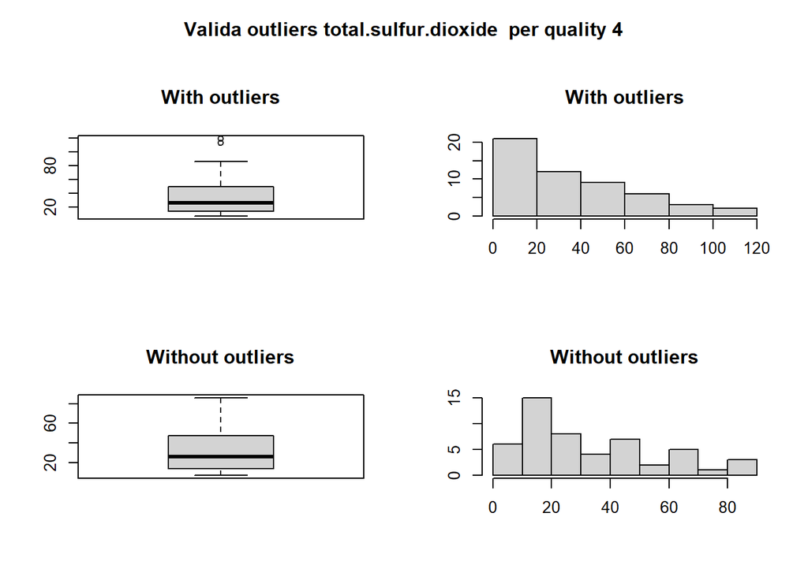

```
## Outliers identificats per la qualitat del vi: 4 :  2
## Proporció (%) de outliers: 3.9
## Mitja dels outliers: 116
## Mitja sense eliminar els outliers: 36.25
## Mitja eliminant outliers: 33.12
```

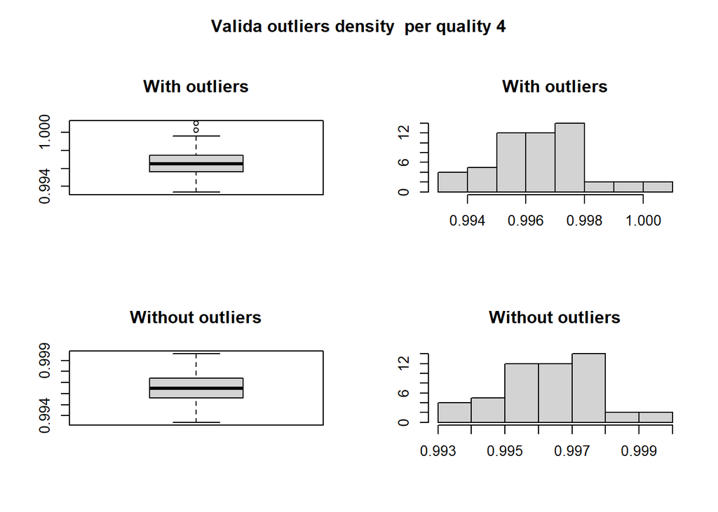

```
## Outliers identificats per la qualitat del vi: 4 :  2
## Proporció (%) de outliers: 3.9
## Mitja dels outliers: 1
## Mitja sense eliminar els outliers: 1
## Mitja eliminant outliers: 1
```

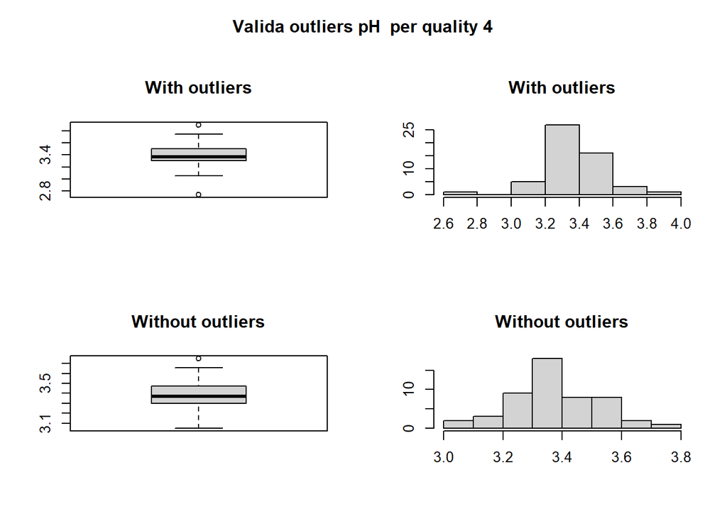

```
## Outliers identificats per la qualitat del vi: 4 :  2
## Proporció (%) de outliers: 3.9
## Mitja dels outliers: 3.32
## Mitja sense eliminar els outliers: 3.38
## Mitja eliminant outliers: 3.38
```

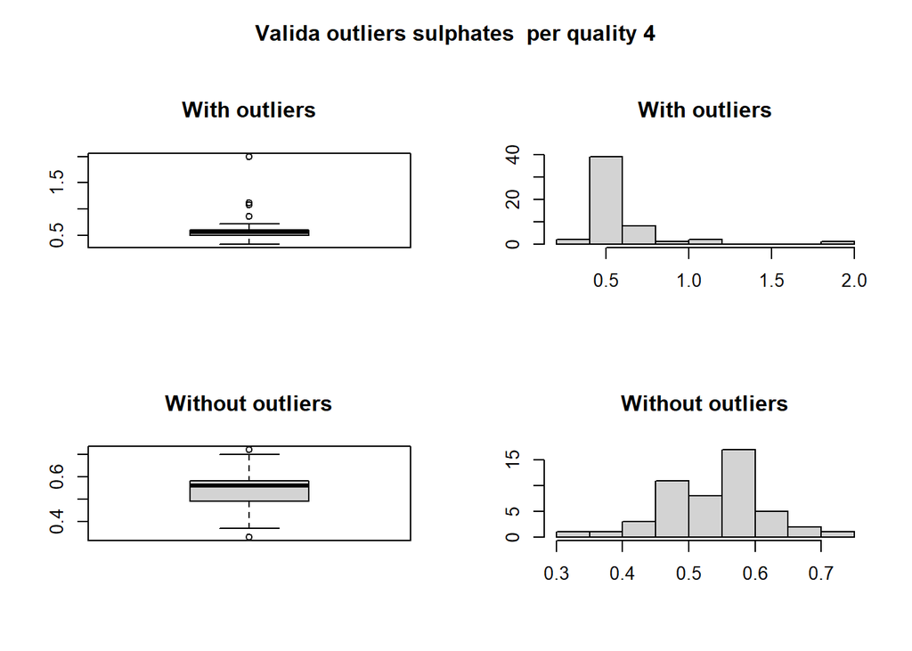

```
## Outliers identificats per la qualitat del vi: 4 :  4
## Proporció (%) de outliers: 8.2
## Mitja dels outliers: 1.27
## Mitja sense eliminar els outliers: 0.6
## Mitja eliminant outliers: 0.54
```

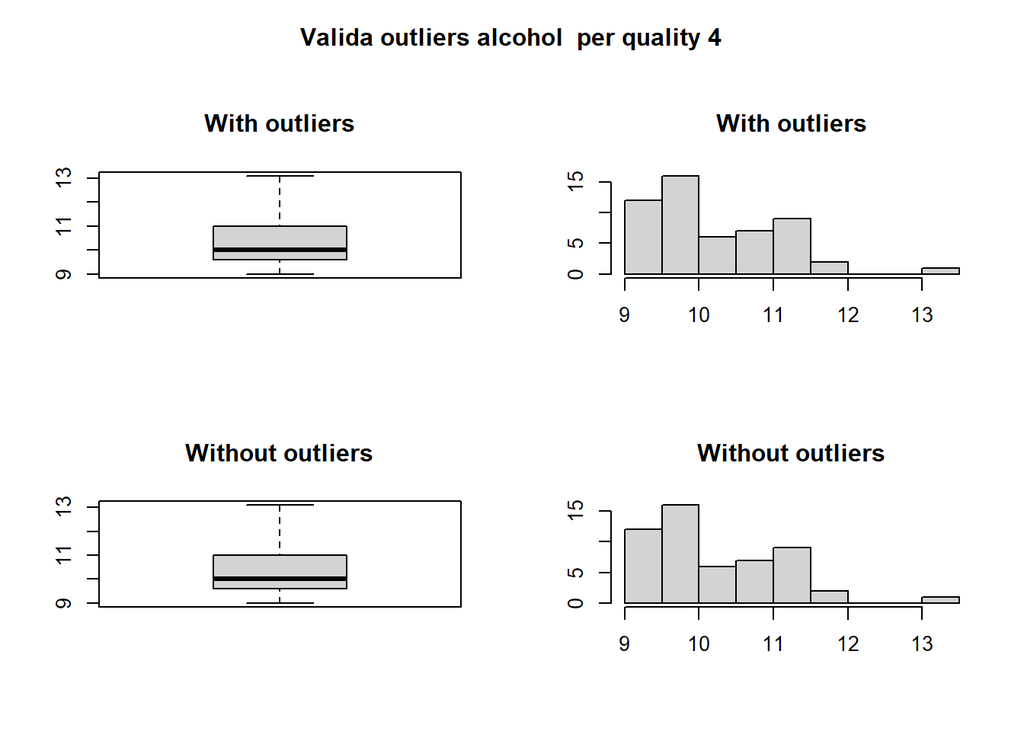

```
## Outliers identificats per la qualitat del vi: 4 :  0
## Proporció (%) de outliers: 0
## Mitja dels outliers: NaN
## Mitja sense eliminar els outliers: 10.27
## Mitja eliminant outliers: 10.27
```

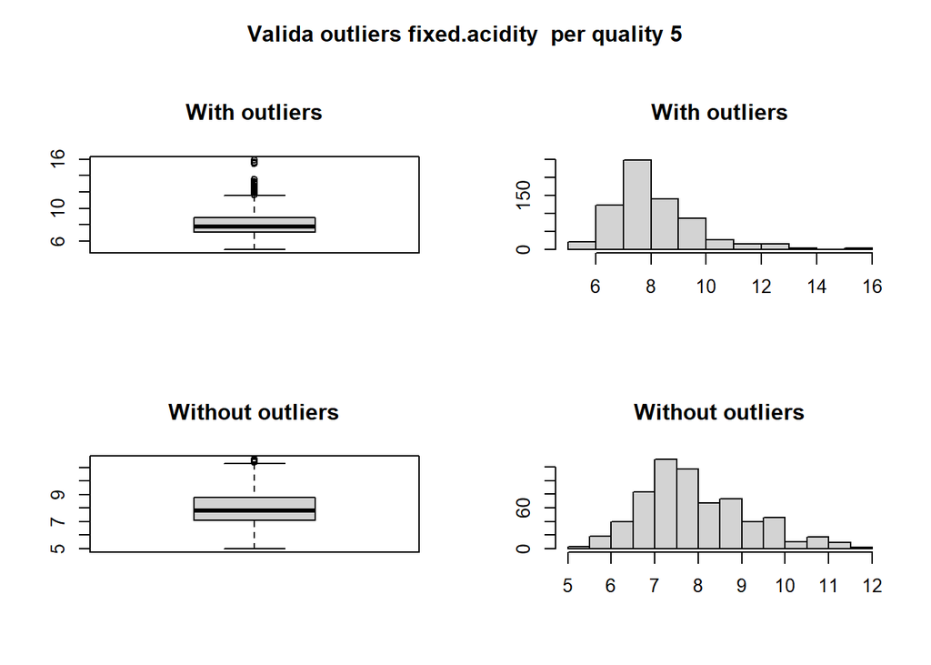

```
## Outliers identificats per la qualitat del vi: 5 :  26
## Proporció (%) de outliers: 4
## Mitja dels outliers: 12.95
## Mitja sense eliminar els outliers: 8.17
## Mitja eliminant outliers: 7.98
```

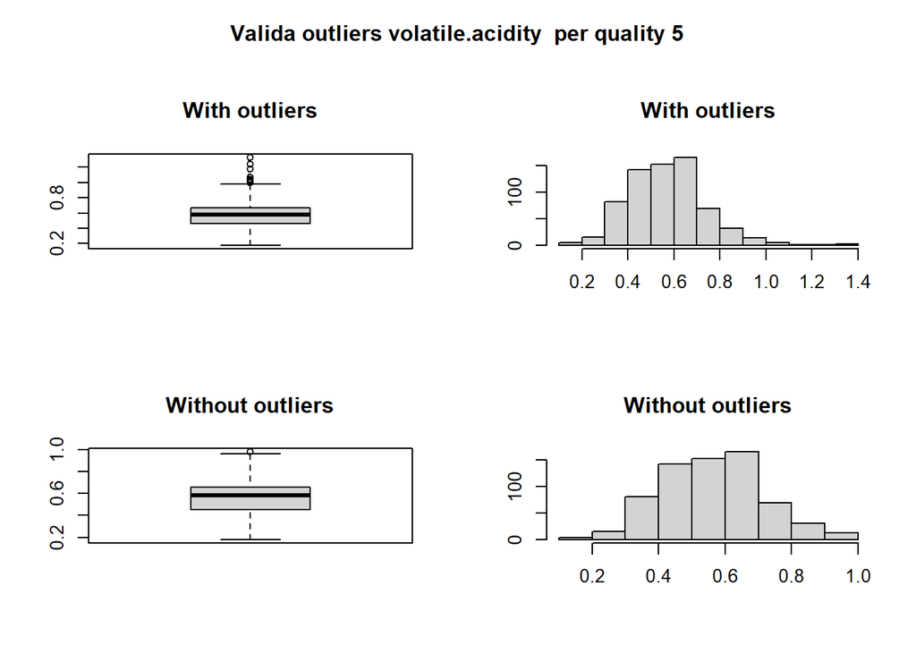

```
## Outliers identificats per la qualitat del vi: 5 :  10
## Proporció (%) de outliers: 1.5
## Mitja dels outliers: 1.13
## Mitja sense eliminar els outliers: 0.58
## Mitja eliminant outliers: 0.57
```

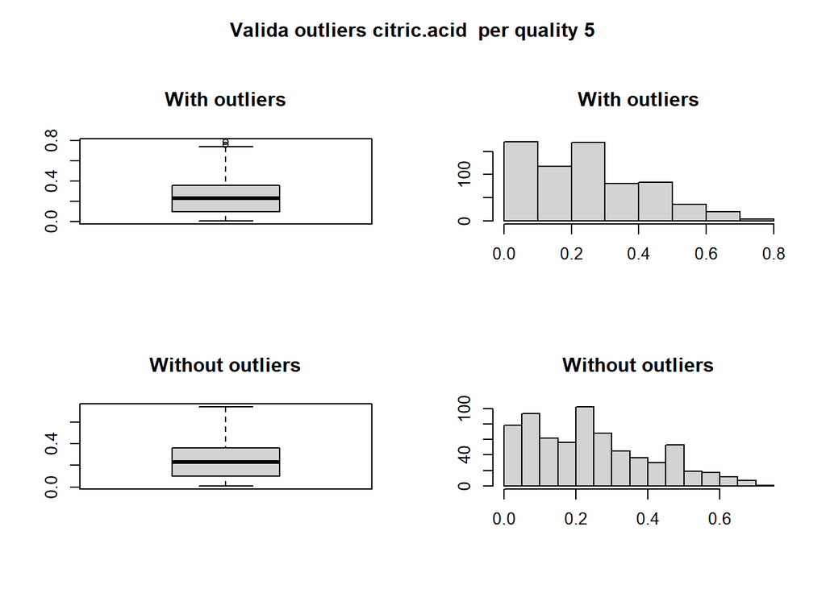

```
## Outliers identificats per la qualitat del vi: 5 :  2
## Proporció (%) de outliers: 0.3
## Mitja dels outliers: 0.78
## Mitja sense eliminar els outliers: 0.25
## Mitja eliminant outliers: 0.25
```

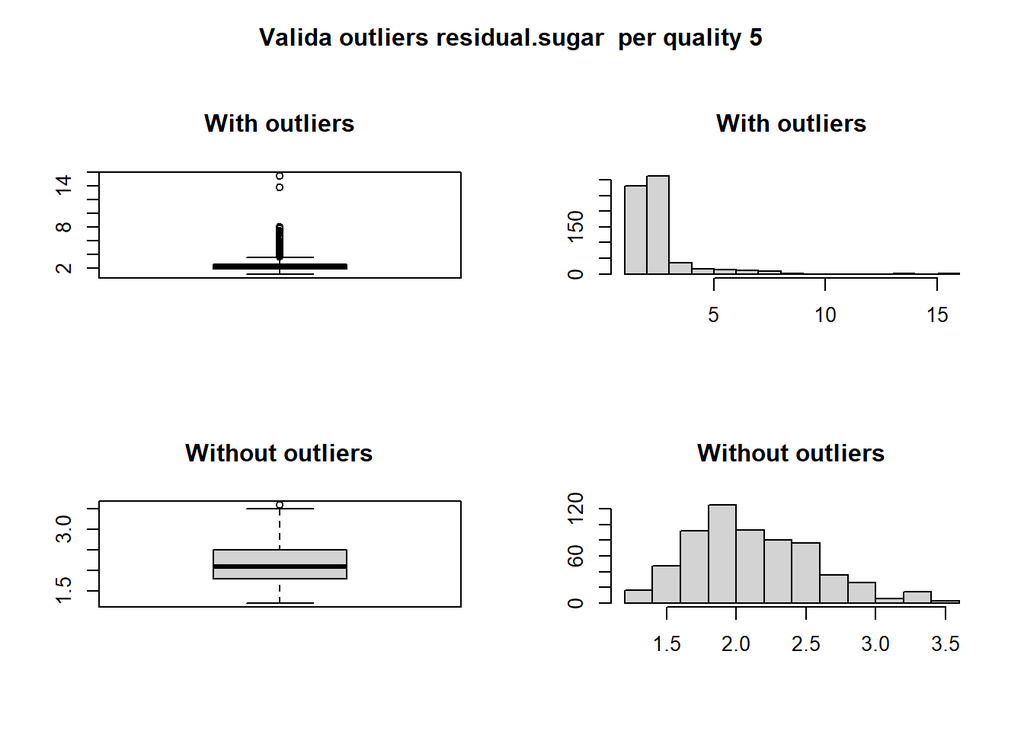

```
## Outliers identificats per la qualitat del vi: 5 :  66
## Proporció (%) de outliers: 10.7
## Mitja dels outliers: 5.81
## Mitja sense eliminar els outliers: 2.53
## Mitja eliminant outliers: 2.18
```